# Moving to North Carolina

# Moving Story

- Currently you live in Juneau and you are taking a new job in Raleigh, North Carolina
- Moving in September
- Question: What’s the mean temperature in Raleigh in September?

# More formally

- You will observe daily September temperature measurements in Raleigh $y_1, ..., y_n$
- Assume $y_j$ are a random sample from a normal curve with mean $\mu$ and standard deviation $\sigma$
- Assume we know $\sigma = 10$
- Have some ``prior" beliefs about $\mu$

# Construct a prior

# Using R function

- Function `normal.select` finds the matching normal curve

```r
library(LearnBayes)
quantile_1 <- list(x = 65, p = .50)
quantile_2 <- list(x = 75, p = .90)
normal.select(quantile_1, quantile_2)
```

```
## $mu
## [1] 65
##
## $sigma
## [1] 7.803041
```

- So my prior is N(65, 7.80)

# Likelihood

- Observe some September temps $y_1, ..., y_n$
- Likelihood is probability of observing these temps viewed as a function of $\mu$

$$L(\mu) = \prod_{j=1}^n f_N(y_j | \mu, \sigma) = f_N\left(\bar y|\mu, \frac{\sigma}{\sqrt{n}}\right)$$

# Posterior

- Posterior $\propto$ Prior $\times$ Likelihood
- Here

$$g(\mu | y) \propto g_N(\mu, 65, 7.8) \times f_N\left(\bar y|\mu, \frac{\sigma}{\sqrt{n}}\right)$$

- Conjugate analysis – prior and posterior are both in normal family

# Nice updating formula

- Precision is the reciprocal of the variance
- Posterior precision is the sum of the prior precision and the data precision

$$P_{post} = \frac{1}{7.8^2} + \frac{n}{\sigma^2}$$
- Posterior mean is weighted average of the sample mean and the prior mean where the weights are proportional to the precisions

$$\frac{n / \sigma^2}{n / \sigma^2 + 1 / 7.8^2} \bar y + \frac{1 / 7.8^2}{n / \sigma^2 + 1 / 7.8^2} 65$$

# Collect some temperatures

- Collect 10 temps, compute $\bar y$ and standard error $\sigma / \sqrt{n}$

```r
library(tidyverse)
Temp <- read_csv("data/temps.csv")
df <- head(select(filter(Temp, Month == 9), Raleigh),
           10)
(ybar <- mean(df$Raleigh))
```

```
## [1] 71.83
```

```r
(se <- 10 / sqrt(10))
```

```
## [1] 3.162278
```

# Use R function to update

```r
library(TeachBayes)
normal_update(c(65, 7.8), c(71.83, 3.16), teach=TRUE)
```

```
##        Type     Mean  Precision Stand_Dev
## 1     Prior 65.00000 0.01643655  7.800000
## 2      Data 71.83000 0.10014421  3.160000
## 3 Posterior 70.86705 0.11658076  2.928779
```

- Posterior is N(70.86, 2.92)

# Prior, Likelihood, and Posterior

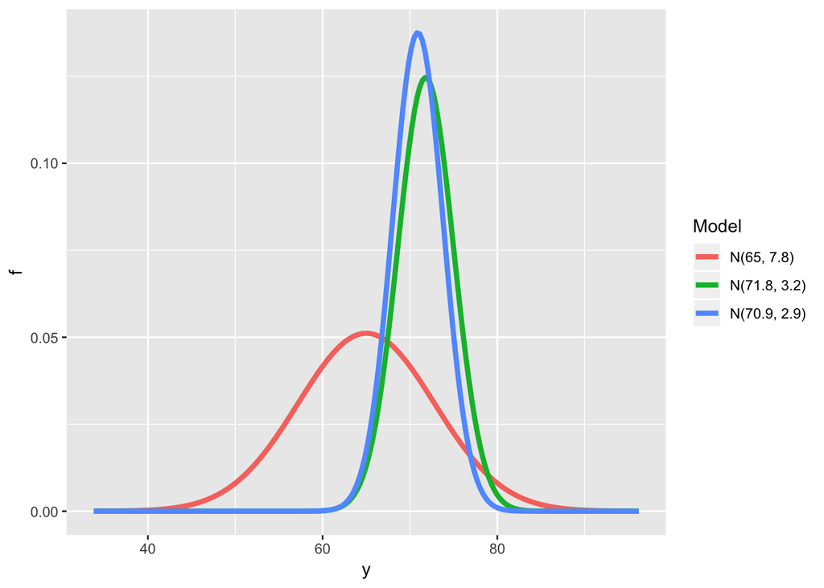

```r
normal_par <- list(c(65, 7.8), c(71.83, 3.16),
                   c(70.86, 2.93))
many_normal_plots(normal_par)
```

# Interval estimate

- A 90% interval estimate is an interval that covers 90% of the posterior

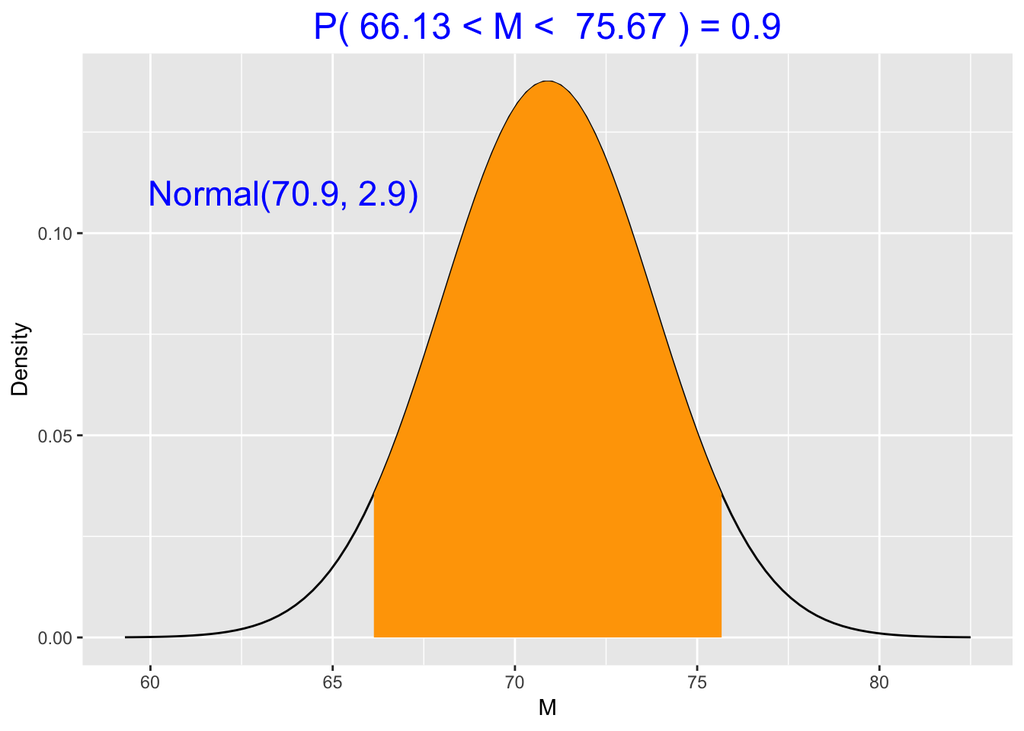

```r
normal_interval(0.9, c(70.9, 2.9))
```

# Is it likely $\mu$ > 75 degrees?

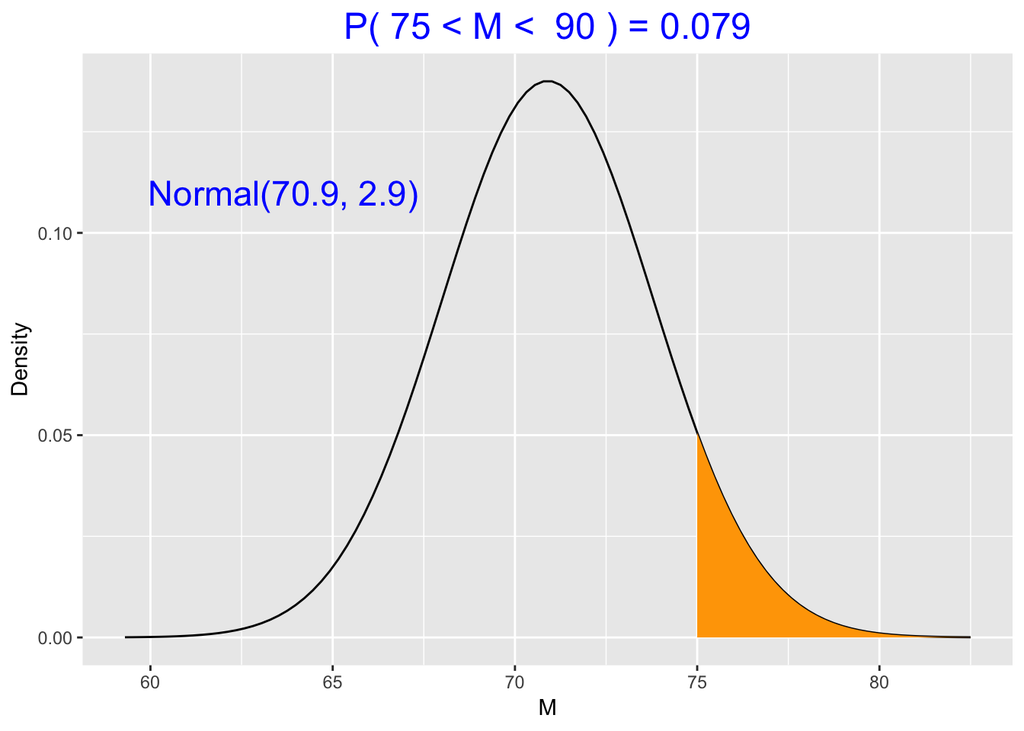

```r
normal_area(75, 90, c(70.9, 2.9))
```

# Prediction

- Want to predict tomorrow’s temperature in Raleigh
- Predictive density of $y^*$

$$f(y^*) = \int f(y^* | \mu) g(\mu | y) \mu$$

- In this normal/normal setting,

$$y^* \sim N(70.9, \sqrt{2.9^2 + 10^2})$$

- Construct a 90% prediction interval

# Aspects of Bayes in this problem

- Incorporate prior beliefs about average temperature
- Use normal density to model beliefs
- Nice conjugate structure – normal prior -> normal posterior
- Inferences about mean found by summarizing posterior
- Straightforward to handle prediction